# StatComp Project 1: Numerical Statistics

Lewis MacRae (s1506414, lew98)

# 1 Confidence interval approximation assessment

## 1.1 multi_pois_CI function implementation

The function is shown in the code appendix.

## 1.2 Equality of type 1 and type 2 confidence interval widths

We will show that, given a sample $\boldsymbol{y}$ and a confidence level $1-\alpha$, the widths of the confidence intervals for $\lambda$ using the type 1 $(\theta = \lambda)$ and type 2 $(\theta = \sqrt{\lambda})$ parameterisations are equal, provided the left endpoints of the confidence intervals for $\theta$ do not extend below $0$.

As shown in the lectures, the confidence interval for $\lambda$ using the type 1 parameterisation is given by

$$\text{CI}_{\lambda} = \left(\overline{y} - \sqrt{\frac{\overline{y}}{n}} z_{1-\alpha/2},\,\, \overline{y} - \sqrt{\frac{\overline{y}}{n}} z_{\alpha/2}\right).$$
We assume that the left endpoint of the interval does not extend below $0$. The width of this interval is then

$$\left(\overline{y} - \sqrt{\frac{\overline{y}}{n}} z_{\alpha/2}\right) - \left(\overline{y} - \sqrt{\frac{\overline{y}}{n}} z_{1-\alpha/2}\right) = \sqrt{\frac{\overline{y}}{n}}(z_{1-\alpha/2} - z_{\alpha/2}) = 2\sqrt{\frac{\overline{y}}{n}}(z_{1-\alpha/2}),$$

where the last equality follows since the standard normal distribution is symmetric about its mean $(0)$, so we have $z_{\alpha/2} = -z_{1-\alpha/2}$.

As shown in the lectures, the confidence interval for $\lambda$ using the type 2 parameterisation (we have again assumed that the confidence interval for $\theta$ does not extend below $0$) is given by

$$\begin{aligned}
\text{CI}_{\lambda} &= \left(\left(\sqrt{\overline{y}} - \frac{1}{2\sqrt{n}} z_{1-\alpha/2}\right)^2,\,\, \left(\sqrt{\overline{y}} - \frac{1}{2\sqrt{n}} z_{\alpha/2}\right)^2\right) \\
&= \left(\overline{y} - \sqrt{\frac{\overline{y}}{n}}z_{1-\alpha/2} + \frac{1}{4n} z^2_{1-\alpha/2},\,\, \overline{y} - \sqrt{\frac{\overline{y}}{n}}z_{\alpha/2} + \frac{1}{4n} z^2_{\alpha/2}\right)
\end{aligned}$$
As noted before, we have $z_{\alpha/2} = -z_{1-\alpha/2}$ and hence $z_{\alpha/2}^2 = z_{1-\alpha/2}^2$. So when calculating the width of the confidence interval above, these terms cancel:

$$\left(\overline{y} - \sqrt{\frac{\overline{y}}{n}}z_{\alpha/2} + \frac{1}{4n} z^2_{\alpha/2}\right) - \left(\overline{y} - \sqrt{\frac{\overline{y}}{n}}z_{1-\alpha/2} + \frac{1}{4n} z^2_{1-\alpha/2}\right) = 2\sqrt{\frac{\overline{y}}{n}}(z_{1-\alpha/2}),$$
which is the same as the width of the confidence interval for the type 1 parameterisation, as desired.

## 1.3 tidy_multi_pois_CI function implementation

The function is shown in the code appendix.

## 1.4 Coverage probability estimation

It is clearly important for a method which generates confidence intervals of a nominal confidence level to actually provide that coverage in practice. To investigate our three parameterisation types, we now use the function `tidy_multi_pois_CI` to estimate the coverage probability for each type of parameterisation with nominal confidence level $1-\alpha$ = 90%. For each type, we take $m = 200000$ samples of length $n = 2$ with true parameter value $\lambda = 3$. The results are shown in the table below.

Estimated coverage probabilities

| Type of parameterisation | Number of intervals containing true parameter value | As percent of total |
| --- | --- | --- |
| 1 | 165889 | 82.94% |
| 2 | 179078 | 89.54% |
| 3 | 188604 | 94.30% |

Of the three types, type 2 is the clear winner for matching the nominal confidence level. Type 1 is about 7% less, and type 3 about 4% more than the desired 90%. We note that when constructing the confidence intervals, we used the fact that for a parameterisation $\theta = f(\lambda)$,

$$\frac{\hat{\theta}_{ML} - \theta_{true}}{\sqrt{I^{-1}(\theta_{true})}} \xrightarrow{d} N(0, 1) \quad \text{as}\,\,n \to \infty$$
where $n$ is the sample size. In our estimation of the coverage probabilities we used a relatively small sample size, $n = 2$, and so the approximation to the standard normal distribution is possibly not very accurate. This could explain the results for the type 1 and 3 parameterisations. Despite this, the type 2 parameterisation does match up well with the nominal confidence level.

## 1.5 Interval width empirical CDFs

Another desirable property for a confidence interval generating method is that of having narrow intervals. Below we plot the empirical CDFs for the widths of each type of confidence interval.

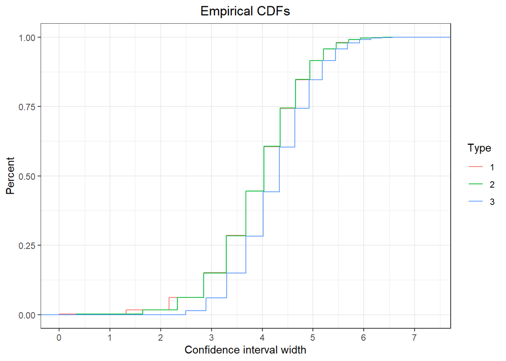

The median width for each type of confidence interval is shown in the table below.

Confidence interval median widths

| Type of parameterisation | Median interval width |
| --- | --- |
| 1 | 4.029052 |
| 2 | 4.029052 |
| 3 | 4.338752 |

In part 1.2 we showed that for a given sample, the type 1 and type 2 parameterisations give confidence intervals of equal widths. The plot above mostly confirms this, and the median widths are equal for those types, but there is some discrepancy towards the lower end of the range of widths. This can be explained by the assumption in our derivation that the left endpoints of the $\theta$ confidence intervals do not extend below $0$. For large $n$ this is a safe assumption to make, however since we are considering only $n = 2$, there may be some sample means which give negative left endpoints for one or both types of parameterisations.

For example, a sample of $y_1 = 1, y_2 = 0$ gives a sample mean of $0.5$, which in turn gives a left endpoint for the type 1 $\lambda$ confidence interval of around $-0.32$ and a right endpoint of around $1.32$. Instead of taking the difference of these to obtain a width of roughly $1.64$, our implementation sets the left endpoint to $0$ which results in a width of about $1.32$. For this sample mean, the type 2 parameterisation does not have the same problem and gives a width of approximately $1.64$. We can see these values on the plot as the first noticeable step up for the type 1 and type 2 CDFs.

The effect of these edge cases is that for some small sample means the type 1 parameterisation gives slightly narrower intervals than the type 2 parameterisation, as we can see from the plot. All things being equal this would give the type 1 parameterisation a slight edge over the type 2, however as shown in part 1.4 the coverage for the type 1 confidence intervals misses the desired nominal confidence level by a large amount and is significantly lower than that of the type 2 - this small improvement isn’t really enough to make up for that.

The plot and the median interval widths show that the type 3 parameterisation gives noticeably larger widths than the other two types. This could, although does not necessarily, explain why the type 3 confidence intervals had the highest estimated coverage probability in part 1.4.

To conclude, the type 2 parameterisation is the closest to the desired nominal confidence level, and indeed is only about half a percent off. The type 3 parameterisation offers a higher coverage probability, but at the cost of larger widths. The type 1 parameterisation has equal and sometimes slightly lower widths than type 2 but misses the desired coverage level by a significant amount. Overall, the type 2 parameterisation is likely the best method, at least for sample sizes of $n = 2$.

# 2 Archaeology in the Baltic sea

## 2.1 Joint probability density function for $(\boldsymbol{N}, \boldsymbol{Y})$

The marginal density is given by “integrating out” $\phi$ from the joint density for $(\boldsymbol{N}, \boldsymbol{Y}, \phi)$:

$$\begin{aligned}
p(\boldsymbol{N}, \boldsymbol{Y}) &= \int_{-\infty}^{\infty} p(\boldsymbol{N}, \boldsymbol{Y}, \phi)\ \text{d}\phi \\
&= \int_{-\infty}^{\infty} p(\boldsymbol{Y} | \boldsymbol{N}, \phi)p(\boldsymbol{N}, \phi)\ \text{d}\phi \\
&= \int_{-\infty}^{\infty} p(\boldsymbol{Y} | \boldsymbol{N}, \phi)p(\boldsymbol{N})p(\phi)\ \text{d}\phi \\
&= \int_{-\infty}^{\infty} \left(\prod_{j=1}^J \prod_{i=1}^2 {N_j \choose Y_{j,i}} \phi^{Y_{j,i}} (1-\phi)^{N_j - Y_{j,i}} \right)\left( \prod_{j=1}^J p(N_j) \right) \left( \frac{\phi^{a-1}(1-\phi)^{b-1}}{B(a,b)} \right) \text{d}\phi. \\
\end{aligned}$$

Now we take everything which does not depend on $\phi$ outside of the integral and collect the $\phi$ and $1-\phi$ terms inside the integral:

$$\begin{aligned}
p(\boldsymbol{N}, \boldsymbol{Y}) &= \frac{1}{B(a,b)} \prod_{j=1}^J \left[p(N_j) \prod_{i=1}^2 {N_j \choose Y_{j,i}}\right] \int_{-\infty}^{\infty} \phi^{\left(a+\sum_{j,i}Y_{j,i}\right)-1} (1-\phi)^{\left(b+2\sum_j N_j-\sum_{j,i}Y_{j,i}\right)-1}\ \text{d}\phi. \\
\end{aligned}$$

Let $\tilde{a} = a + \sum_{j,i}Y_{j,i}$ and $\tilde{b} = b+2\sum_j N_j-\sum_{j,i}Y_{j,i}$, as in the question. We notice that the integrand is almost the density function for a $\text{Beta}(\tilde{a}, \tilde{b})$ distribution, so we multiply by $1 = B(\tilde{a}, \tilde{b}) / B(\tilde{a}, \tilde{b})$ like so:

$$\begin{aligned}
p(\boldsymbol{N}, \boldsymbol{Y}) &= \frac{B(\tilde{a}, \tilde{b})}{B(a,b)} \prod_{j=1}^J \left[p(N_j) \prod_{i=1}^2 {N_j \choose Y_{j,i}}\right] \int_{-\infty}^{\infty} \frac{1}{B(\tilde{a}, \tilde{b})} \phi^{\tilde{a}-1} (1-\phi)^{\tilde{b}-1}\ \text{d}\phi. \\
\end{aligned}$$

Then the desired result follows since the integrand is now the density function for a $\text{Beta}(\tilde{a}, \tilde{b})$ distribution:

$$\begin{aligned}
p(\boldsymbol{N}, \boldsymbol{Y}) &= \frac{B(\tilde{a}, \tilde{b})}{B(a,b)} \prod_{j=1}^J \left[p(N_j) \prod_{i=1}^2 {N_j \choose Y_{j,i}}\right].
\end{aligned}$$

## 2.2 log_prob_NY function implementation

The function is shown in the code appendix.

## 2.3 arch_importance function implementation

The function is shown in the code appendix.

## 2.4 Credible intervals for $N_j$

Here we use the `arch_importance` and `wquantile` functions with $K = 25000$ samples and hyperparameters $\xi = 1/1001, a = b = 1/2$ to generate $1-\alpha$ = 90% credible intervals for each $N_j$ and observe how these change as more data is added. Also shown is the full set of data for the excavations.

Credible intervals for $N_j$

|  | 1 excavation | 2 excavations | 3 excavations | 4 excavations |
| --- | --- | --- | --- | --- |
| $N_1$ | (301, 1431) | (375, 3481) | (425, 3019) | (528, 1657) |
| $N_2$ | NA | (40, 392) | (47, 348) | (60, 212) |
| $N_3$ | NA | NA | (207, 1501) | (255, 826) |
| $N_4$ | NA | NA | NA | (945, 2755) |

Archaeology data

|  | $y_1$, left femurs | $y_2$, right femurs |
| --- | --- | --- |
| Excavation $j = 1$ | 256 | 237 |
| Excavation $j = 2$ | 29 | 24 |
| Excavation $j = 3$ | 112 | 121 |
| Excavation $j = 4$ | 428 | 407 |

We could compare the values with the quantiles from the prior distribution. For a $\text{Geom(1/1001)}$ distribution, the $(0.05, 0.95)$ quantiles are

```
## [1] "(51, 2997)"
```

However, this may be of limited use given that we are assuming a common femur detection rate across all excavations and the number of femurs found at each digsite is noticeably different - it does not seem particularly useful to compare this to the $N_2$ credible intervals, for example. One thing that is useful is that these quantiles are very far from the mean for the geometric distribution $(1001)$, so our credible intervals being quite wide isn’t so surprising.

To conclude, getting a narrow credible interval for the number of people buried at a gravesite seems to be a difficult task, at least with this data and model. If an archaeologist found say $x$ left femurs at an excavation, based on this analysis we could say that the number of people buried at that excavation is likely to be in the range $(2x, 8x)$.

## 2.5 Credible intervals for $\phi$

Now we construct 90% credible intervals for $\phi$ using the same importance samples as for the $N_j$ credible intervals and observe how these change as more data is added.

Credible intervals for $\phi$

|  | 1 excavation | 2 excavations | 3 excavations | 4 excavations |
| --- | --- | --- | --- | --- |
| $\phi$ | (0.172, 0.818) | (0.071, 0.652) | (0.076, 0.581) | (0.148, 0.454) |

As more excavations are added, the intervals decrease in width but even with 4 excavations are quite wide. We can compare these with the quantiles from the prior distribution. For a $\text{Beta}(1/2, 1/2)$ distribution, the $(0.05, 0.95)$ quantiles are

```
## [1] "(0.006, 0.994)"
```

This does not tell us much more than the obvious $0 \leq \phi \leq 1$, so the constructed credible intervals provide quite an improvement over the prior distribution.

We note that the decrease in width as excavations are added comes mostly from the the upper endpoint decreasing. A reasonable conclusion to draw is that the chance to find a femur of either type at a gravesite is likely no more than 50%, and probably much lower.

# 3 Code appendix

## 3.1 Function definitions

```r
# Lewis MacRae (s1506414, lew98)
# Place your function definitions and associated code documentation my_code.R

#' Approximate confidence intervals for many samples
#'
#' CI1, CI2, and CI3, are the three confidence interval constructors from
#' lab 4, for the expectation parameter in a Poisson distribution
#'
#' @param m number of samples to simulate
#' @param n number of observations for each sample
#' @param lambda true parameter value for each sample
#' @param alpha The nominal (desired) error probability for the
#'   confidence interval.
#'   Default: 0.05, to get 95% confidence intervals
#' @param type 1, 2, or 3, selecting one of the three parameterisation
#'   alternatives, theta=lambda, theta=sqrt(lambda), or theta=log(lambda).
#'   Default: 1
#'
#' @return A data frame with m rows and two columns, Lower and Upper. Each
#'   row contains a confidence interval

multi_pois_CI <- function(m, n, lambda, alpha = 0.05, type = 1) {
  lwr <- numeric(length = m)
  upr <- numeric(length = m)

  for (i in 1:m) {
    # Simulate a sample and calculate the CI of the desired type
    CI <- rpois(n = n, lambda = lambda) %>%
      pois_CI(alpha = alpha, type = type)
    lwr[[i]] <- CI[[1]]
    upr[[i]] <- CI[[2]]
  }

  data.frame(Lower = lwr, Upper = upr)
}

#' Approximate confidence intervals for many samples, all three types
#'
#' @param m number of samples to simulate
#' @param n number of observations for each sample
#' @param lambda true parameter value for each sample
#' @param alpha The nominal (desired) error probability for the
#'   confidence interval.
#'   Default: 0.05, to get 95% confidence intervals
#'
#' @return A data.frame with 3*m rows and three columns, Lower, Upper and Type.
#'   Each row contains a confidence interval and associated type

tidy_multi_pois_CI <- function(m, n, lambda, alpha = 0.05) {
  df1 <- cbind(multi_pois_CI(m = m, n = n, lambda = lambda, alpha = alpha, type = 1), Type = 1)
  df2 <- cbind(multi_pois_CI(m = m, n = n, lambda = lambda, alpha = alpha, type = 2), Type = 2)
  df3 <- cbind(multi_pois_CI(m = m, n = n, lambda = lambda, alpha = alpha, type = 3), Type = 3)

  rbind(df1, df2, df3)
}

#' Log probability density function for (N, Y) joint distribution
#'
#' @param N vector of observations for N, each N_j is the number of people
#'   buried at excavation j
#' @param Y data.frame of observations for Y, each row j contains the number of
#'   left (first column) and right (second column) femurs found at excavation j
#' @param xi hyperparameter for prior distribution of N ~ Geom(xi).
#'   Default: 1/1001 for ease of use, since only this value is used in the report
#' @param a first hyperparameter for prior distribution of phi ~ Beta(a, b).
#'   Default: 1/2 for ease of use, since only this value is used in the report
#' @param b second hyperparameter for prior distribution of phi ~ Beta(a, b).
#'   Default: 1/2 for ease of use, since only this value is used in the report
#'
#' @return If the combination of N and Y is valid, returns a single numeric
#'   value, the log density for the given observations and hyperparameters.
#'   Otherwise, returns -Inf.

log_prob_NY <- function(N, Y, xi = 1 / 1001, a = 1 / 2, b = 1 / 2) {
  # Check if N and Y observations are valid - we must have for each j that
  # N_j >= Y_j,1 and Y_j,2 since we are assuming that we cannot find more of
  # either kind of femur at an excavation than there are people buried there.
  if (all(N >= Y)) {
    # If the combination is valid, return the log of the joint density derived
    # in part 2.1 of the report.
    lbeta(a + sum(colSums(Y)), b + 2 * sum(N) - sum(colSums(Y))) - lbeta(a, b) +
      sum(dgeom(N, xi, log = TRUE) +
        rowSums(
          as.data.frame(
            vapply(Y, function(x) lchoose(N, x), numeric(length(N)))
          )
        ))
  } else {
    -Inf
  }
}

#' Importance sampling function, alternative sampling distribution
#'
#' @param K number of samples to take
#' @param Y data.frame of observations for Y, each row j contains the number of
#'   left (first column) and right (second column) femurs found at excavation j
#' @param xi hyperparameter for prior distribution of N ~ Geom(xi).
#'   Default: 1/1001 for ease of use, since only this value is used in the report
#' @param a first hyperparameter for prior distribution of phi ~ Beta(a, b).
#'   Default: 1/2 for ease of use, since only this value is used in the report
#' @param b second hyperparameter for prior distribution of phi ~ Beta(a, b).
#'   Default: 1/2 for ease of use, since only this value is used in the report
#'
#' @return A data.frame with K rows and J (number of rows of Y) + 2 columns. The
#'   first J columns contain the samples for each N_j, the second last column
#'   contains the samples for phi and the last column contains the log_weights
#'   for the N_j's

arch_importance <- function(K, Y, xi = 1 / 1001, a = 1 / 2, b = 1 / 2) {
  # Get the number of excavations
  J <- nrow(Y)
  # Matrix of minimum allowed value to sample for N, each N_j must be greater
  # than or equal to the maximum of Y_j,1 and Y_j,2
  N_min <- matrix(rep(pmax(Y[, 1], Y[, 2]), each = K), K, J)
  # Parameters to use for sampling the N_j's
  xi_sample <- 1 / (1 + 4 * N_min)
  # Matrix of samples for N
  N <- matrix(rgeom(K * J, prob = xi_sample), K, J) + N_min

  # Samples for phi from the posterior distribution, one phi-sample for each row
  # of N-samples
  phi <- vapply(
    1:K,
    function(x) (rbeta(1, a + sum(colSums(Y)), b + 2 * sum(N[x, ]) - sum(colSums(Y)))),
    numeric(1)
  )

  # Now we calculate the log_weights. Call log_prob_NY for each row of N-samples
  log_PY <- vapply(
    1:K,
    function(x) (log_prob_NY(N[x, ], Y, xi, a, b)),
    numeric(1)
  )
  # Subtract the log density for the N-samples
  log_weights <- log_PY - rowSums(dgeom(N - N_min, prob = xi_sample, log = TRUE))
  # Normalise the log_weights by subtracting the maximum log_weight
  log_weights <- log_weights - max(log_weights)

  df <- as.data.frame(cbind(N, phi, log_weights))
  colnames(df) <- c(paste("N", seq_len(J), sep = ""), "Phi", "Log Weights")
  df
}
```

## 3.2 Analysis code

Code chunk for estimating coverage probabilities in 1.4

```r
set.seed(352)
CIs <- tidy_multi_pois_CI(m = 200000, n = 2, lambda = 3, alpha = 0.1)
CIs_valid <- CIs %>%
             filter(Lower <= 3 & Upper >= 3) %>%
             group_by(Type) %>%
             summarise(n = n()) %>%
             mutate(perc = percent(n / 200000, accuracy = 0.01))
knitr::kable(CIs_valid, col.names = c("Type of parameterisation", "Number of intervals containing true parameter value", "As percent of total"),
             align = "ccc", caption = "Estimated coverage probabilities")
```

Code chunk for displaying the $N_j$ credible intervals in 2.4

```r
# Helper function which takes two values x, y given as a list/vector and formats
# them like an open interval. Returns a string like "(x, y)", rounds to
# 3 decimal places if x not an integer
CI_string <- function(endpoints) {
  if (endpoints[1]%%1 == 0) {
    sprintf("(%i, %i)", endpoints[1], endpoints[2])
  } else {
    sprintf("(%.3f, %.3f)", endpoints[1], endpoints[2])
  }
}

# Helper function to produce a 4x4 data.frame of 90% credible intervals for N_j,
# Column j corresponds to including j excavations in the data, row i contains
# the credible interval for N_i
N_j_CIs <- function(samples) {
  CIs <- matrix(NA, 4, 4)
  for (i in 1:4) {
    for (j in 1:4) {
      if (j >= i) {
        CIs[i, j] = CI_string(wquantile(samples[[j]][[i]],
                                        probs = c(0.05, 0.95), type = 1,
                                        weights = exp(samples[[j]]$`Log Weights`)))
      }
    }
  }
  colnames(CIs) <- c("J1", "J2", "J3", "J4")
  rownames(CIs) <- c("$N_1$", "$N_2$", "$N_3$", "$N_4$")
  as.data.frame(CIs)
}

arch_imp_samples <- lapply(1:4, function(x) arch_importance(25000, arch_data(x)))

excavation_data <- arch_data(4)
rownames(excavation_data) <- c("Excavation $j = 1$", "Excavation $j = 2$", "Excavation $j = 3$", "Excavation $j = 4$")

knitr::kable(N_j_CIs(arch_imp_samples),
             col.names = c("1 excavation", "2 excavations", "3 excavations", "4 excavations"),
             align = "cccc",
             caption = "Credible intervals for $N_j$")
knitr::kable(excavation_data,
             col.names = c("$y_1$, left femurs", "$y_2$, right femurs"),
             align = "cc",
             caption = "Archaeology data")
```

Code chunk for displaying the $\phi$ credible intervals in 2.5

```r
phi_CIs_df <- as.data.frame(lapply(1:4, function(x) {
  CI_string(wquantile(arch_imp_samples[[x]]$Phi, probs = c(0.05, 0.95), type = 7, weights = exp(arch_imp_samples[[x]]$`Log Weights`)))
}))
colnames(phi_CIs_df) <- c("J1", "J2", "J3", "J4")
rownames(phi_CIs_df) <- c("$\\phi$")

knitr::kable(phi_CIs_df,
             col.names = c("1 excavation", "2 excavations", "3 excavations", "4 excavations"),
             align = "cccc",
             caption = "Credible intervals for $\\phi$")
```